# Lab 12

Byoungwook Jang

December 1st, 2017

Now you can download the RMarkdown file by clicking the button in the rupper right corner of this html page.

## Optimization?

As we have done with the rejection method, when you are trying to derive the *BEST* algorithm or parameters, you need to solve a proposed optimization problem. What is an optimization problem then? It looks something like

$$x^* = argmax_{x\in X} f(x)$$
where we call $f$ is the objective function, and $x^*$ is our solution.

### Example from class

Let’s stick with the example from the class. We have that
$$f(x,y) = \exp \left[ -\frac{1}{2} (x^2y^2 + x^2 + y^2 - 8x - 8y)\right]$$
We can look at the contours of the function as following

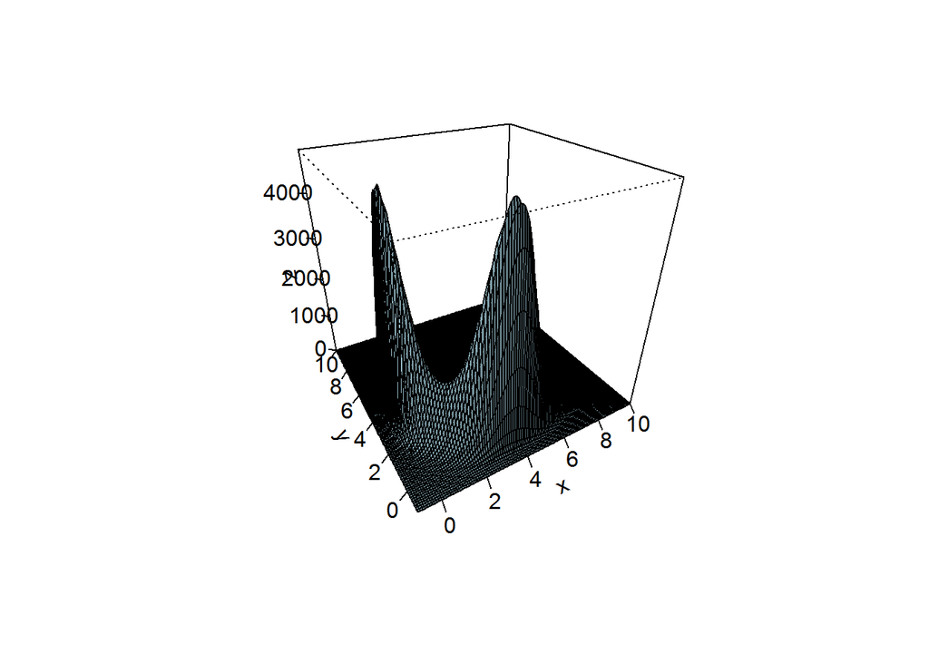

```r
f_fun=function(x,y){
  z=exp(-0.5*(x^2*y^2+x^2+y^2-8*x-8*y))
  return(z)
}
x=seq(from=-1,to=10,by=0.1)
y=x
z=outer(x,y,f_fun) # create matrix of values of $f$ on grid.
library('lattice')
#3-d plotting
persp(x,y,z,theta=-30,phi=30,col='lightblue', ticktype='detailed',shade=0.4)
```

If we want to see this 3-D plot in a more informative way, we can look at

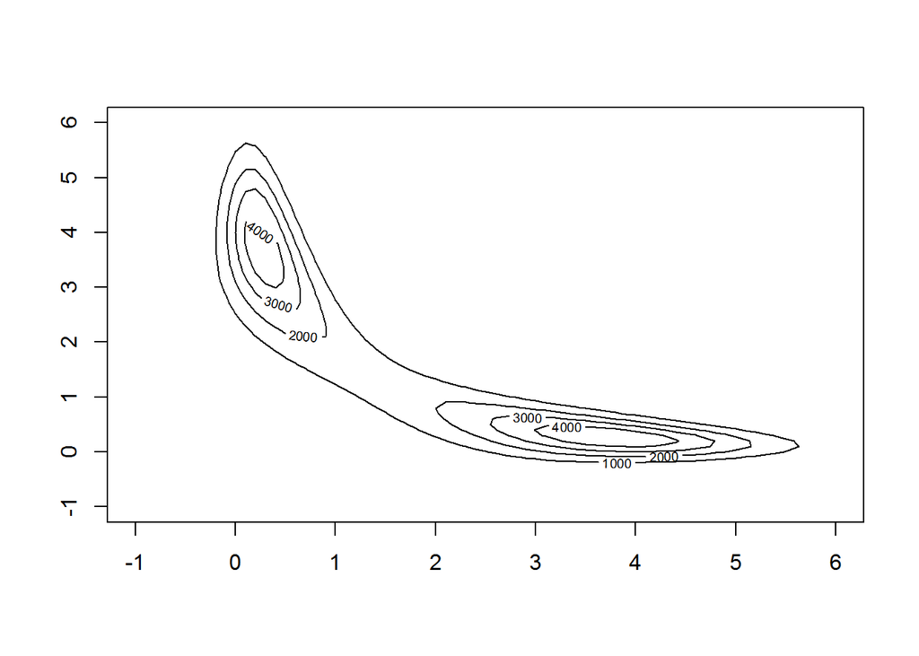

```r
contour(x,y,z, nlevels=5, xlim=c(-1, 6), ylim=c(-1,6))
```

Then, what’s the gradient $\nabla f(x,y)$? Here, the gradient is defined as
$$\nabla f(x,y) =
\begin{bmatrix} \frac{\partial f}{\partial x} \\ \frac{\partial f}{\partial y}
\end{bmatrix}$$
Just think of this vector as a multivariate version of the first derivative. If we actually derive this in terms with our example function $f$, we have that $$
$$\begin{align*}
\nabla f(x,y) & =
\begin{bmatrix} \frac{\partial f}{\partial x} \\ \frac{\partial f}{\partial y}
\end{bmatrix} \\
& = \begin{bmatrix}
\exp \left[ -\frac{1}{2} (x^2y^2 + x^2 + y^2 - 8x - 8y)\right] (xy^2 + x - 4) \; \; \\
\exp \left[ -\frac{1}{2} (x^2y^2 + x^2 + y^2 - 8x - 8y)\right] (x^2y + y - 4) \; \;
\end{bmatrix}
\end{align*}$$

$$ Intuitively, we would try to solve $\nabla f(x,y) = 0$ to find the local maximizer $(x^*, y^*)$. However, it seems like our gradient $\nabla f(x,y)$ isn’t looking good. What do we do??

## Optimization Methods

This is where the optimization methods come in. We will cover two methods, gradient descwent and newton-raphson.

### Gradient Descent

The idea behind the gradient method is simple. We build a linear approximation at the current point, and move one step at a time.

Algorithm (Gradient Descent Method) *Input*: initial point $x_0$, stepsize $\lambda$

1. Start with an initial point $x_0$

While $condition < \epsilon$

2. *Update*: $x_{n+1} = x_n - \lambda f'(x_n)$
3. Current stop condition = $\frac{|x_{n+1} - x_n|}{|x_n| + \epsilon}$

Algorithm (Gradient Descent Method) *Input*: initial point $x_0$, stepsize $\lambda$

1. Start with an initial point $x_0$

While $condition < \epsilon$

2. *Update*: $x_{n+1} = x_n - \lambda \nabla f(x_n)$
3. Current stop condition = $\frac{||x_{n+1} - x_n||}{||x_n + \epsilon||}$

Let’s look at a very simple univariate case, $g(x) = x^2$. Then, the intuition is as follows

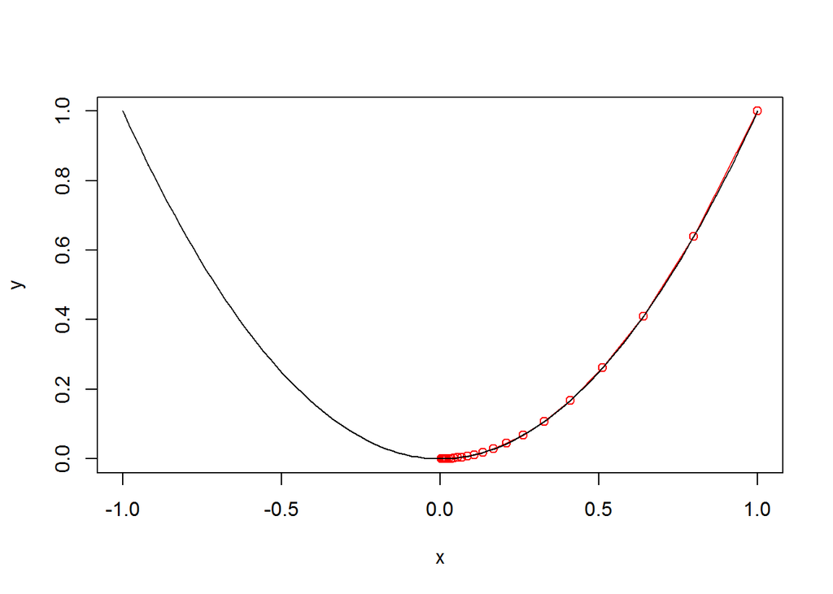

```r
gd_quad = function(step_size, init_point = 1, tol=1e-3, max_iter = 100){
  iter_points = data.frame(x=rep(NA, max_iter), y=rep(NA, max_iter))
  curr_diff = 1
  t = 1
  iter_points$x[1] = init_point
  iter_points$y[1] = init_point^2

  while(curr_diff > tol && t < max_iter){
    curr_grad = 2*iter_points$x[t]
    iter_points$x[t+1] = iter_points$x[t] - step_size*curr_grad
    iter_points$y[t+1] = (iter_points$x[t+1])^2
    curr_diff = abs(iter_points$x[t+1] - iter_points$x[t])
    t = t+1
  }
  return(iter_points)
}

quad_iterations = gd_quad(0.1, 1)
plot(quad_iterations$x, quad_iterations$y, col='red', xlim=c(-1,1), xlab='x', ylab='y')
lines(quad_iterations$x, quad_iterations$y, col='red')

true_x = seq(-1, 1, length.out = 100)
lines(true_x, true_x^2)
```

Note that we have a challenge on choosing the stepsize $\lambda$. Usually, we can use the backtracking method.

### Multivariate case example

Let’s continue to work with

$$f(x,y) = x^2 + y^2$$

$$
$$\begin{align*}
\nabla f(x,y) & =
\begin{bmatrix} \frac{\partial f}{\partial x} \\ \frac{\partial f}{\partial y}
\end{bmatrix} \\
& = \begin{bmatrix}
2x \\ 2y
\end{bmatrix}
\end{align*}$$

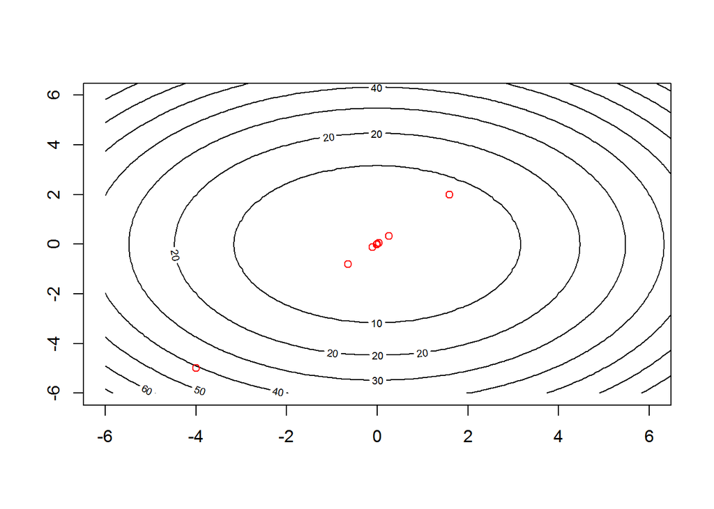

```r
f_fun=function(x,y){
  z=x^2 + y^2
  return(z)
}

grad_f = function(input){
  x = input[1]
  y = input[2]
  d_x = 2*x
  d_y = 2*y
  return(c(d_x, d_y))
}

gd_quad = function(step_size, init_point = c(1,1), tol=1e-5, max_iter = 10000){
  iter_points = list(x=matrix(NA, nrow = max_iter, ncol=2), iter_diff = rep(NA, max_iter))
  curr_diff = 1
  t = 1
  iter_points$x[t,] = init_point

  while(curr_diff > tol && t < max_iter){
    curr_grad = grad_f(iter_points$x[t,])
    iter_points$x[t+1,] = iter_points$x[t, ] - step_size*curr_grad
    v = f_fun(iter_points$x[t,1], iter_points$x[t,2])

    while (f_fun(iter_points$x[t+1,1], iter_points$x[t+1,2])>v){
      step_size = step_size/2;
      iter_points$x[t+1,] = iter_points$x[t, ] - step_size*curr_grad
    }

    iter_points$x[t+1,] = iter_points$x[t, ] - step_size*curr_grad
    curr_diff = sum(curr_grad^2)
    iter_points$iter_diff[t] = curr_diff
    t = t+1
  }
  return(iter_points)
}

init_point = c(-4, -5)
quad_iterations = gd_quad(0.7, init_point)


x=seq(from=-6,to=10,by=0.1)
y=x
z=outer(x,y,f_fun)

contour(x,y,z,  nlevels = 15, xlim=c(-6, 6), ylim=c(-6,6))
par(new=TRUE)
points(quad_iterations$x[,1], quad_iterations$x[,2], col='red')
```

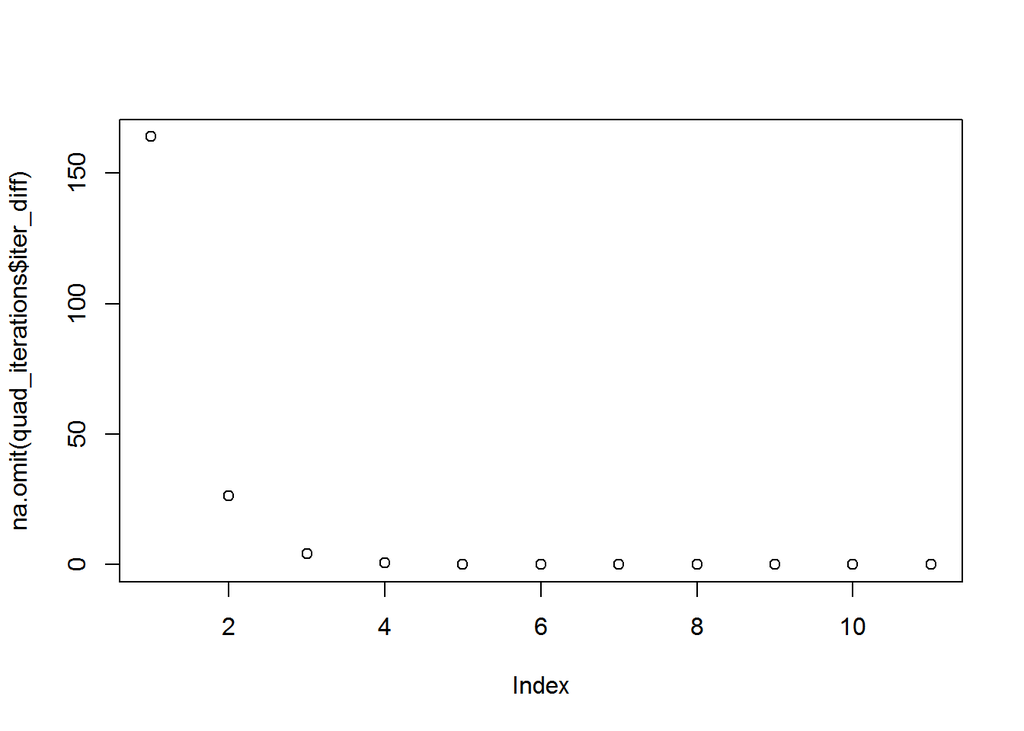

```r
plot(na.omit(quad_iterations$iter_diff))
```

## Newton-Raphson Method

Algorithm (Newton-Raphson Method) *Input*: initial point $x_0$, stepsize $\lambda$

1. Start with an initial point $x_0$

While $condition < \epsilon$

2. *Update*: $x_{n+1} = x_n - \frac{f'(x_n)}{f''(x_n)}$
3. Current stop condition = $\frac{|x_{n+1} - x_n|}{|x_n| + \epsilon}$

Algorithm (Newton-Raphson Method) *Input*: initial point $x_0$, stepsize $\lambda$

1. Start with an initial point $x_0$

While $condition < \epsilon$

2. *Update*: $x_{n+1} = x_n - (\nabla^2f(x_n))^{-1} \cdot \nabla f(x_n)$
3. Current stop condition = $\frac{||x_{n+1} - x_n||}{||x_n + \epsilon||}$

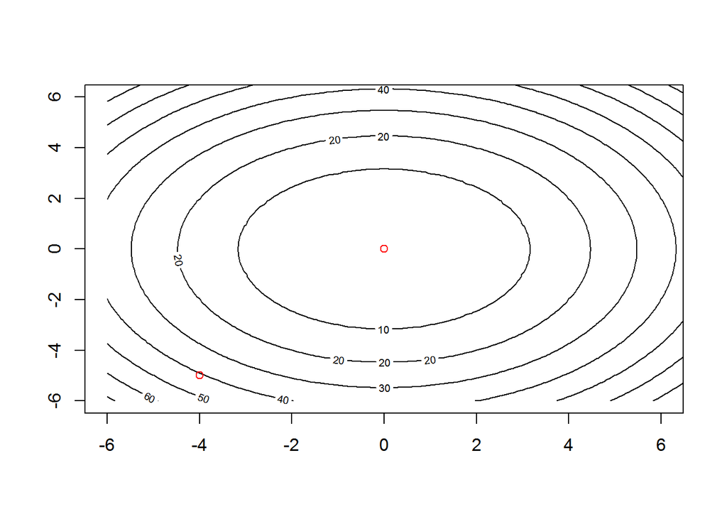

```r
grad_f = function(input){
  x = input[1]
  y = input[2]
  d_x = 2*x
  d_y = 2*y
  return(c(d_x, d_y))
}

hessian_f = function(input){
  return(2*diag(2))
}

nr_quad = function(init_point = c(1,1), tol=1e-5, max_iter = 10000){
  iter_points = list(x=matrix(NA, nrow = max_iter, ncol=2), iter_diff = rep(NA, max_iter))
  curr_diff = 1
  t = 1
  iter_points$x[t,] = init_point

  while(curr_diff > tol && t < max_iter){
    curr_grad = grad_f(iter_points$x[t,])
    curr_hess = hessian_f(iter_points$x[t,])
    iter_points$x[t+1,] = iter_points$x[t, ] - solve(curr_hess, curr_grad)
    curr_diff = sum(curr_grad^2)
    iter_points$iter_diff[t] = curr_diff
    t = t+1
  }
  return(iter_points)
}

init_point = c(-4, -5)
quad_iterations = nr_quad(init_point)

f_fun=function(x,y){
  z=x^2 + y^2
  return(z)
}
x=seq(from=-6,to=10,by=0.1)
y=x
z=outer(x,y,f_fun)

contour(x,y,z,  nlevels = 15, xlim=c(-6, 6), ylim=c(-6,6))
par(new=TRUE)
points(quad_iterations$x[,1], quad_iterations$x[,2], col='red')
```

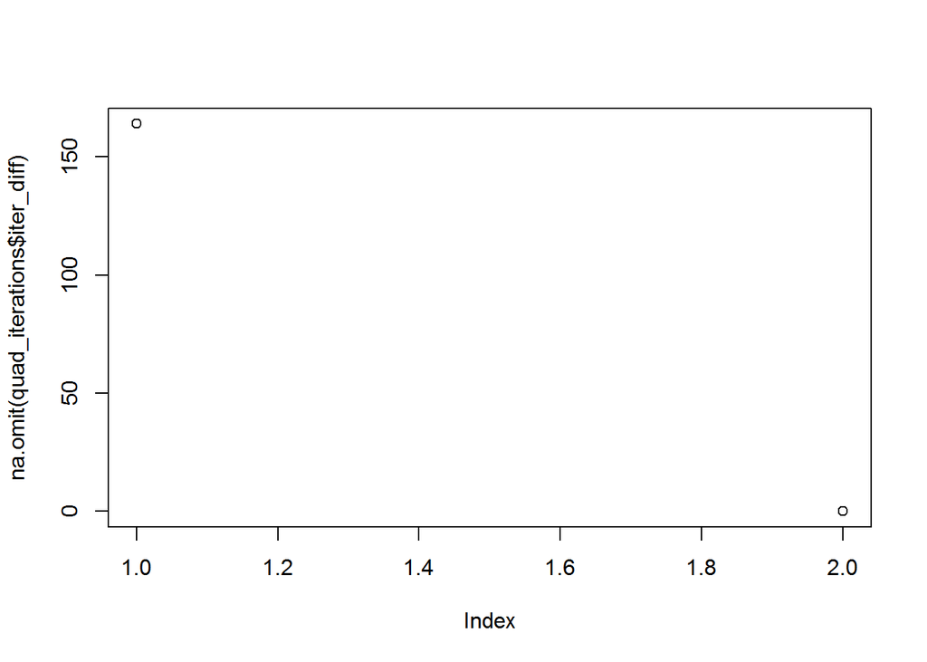

```r
plot(na.omit(quad_iterations$iter_diff))
```